# World Cup Winner - Semifinals Edition

Lukas Heck

2018-07-09

Since Croatia beat Russia on Saturday, the Semifinals for this year’s World Cup are set:

- England
- Belgium
- France
- Croatia

I wanted to see wether the variance in odds between bookmarkers allows to draw conclusions on who will actually win (of course, it most likely will not). Without further ado, here is the final plot:

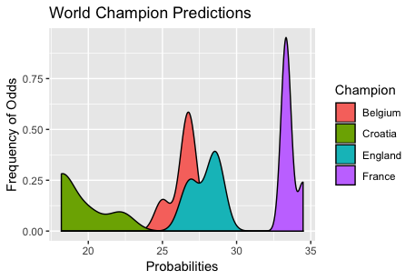

The y-Axis highlights the frequency of a given odd while the x-axis shows the probability of a given team taking the title home. As we can clearly see, France leads by a margin of over 5%. Belgium/England follow and Croatia is far behind.

## Scraping soccer odds and visualizing the results (aka how to produce the plot)

So, let’s get to it: I found a decent site for different betting sources here: https://www.wettfreunde.net/wm-2018-quoten/. Since the link luckily contains a html-table, scraping is rather arbitrary:

```
library(XML)
library(RCurl)
library(rlist)
require(tidyverse)
```

```
theurl <- getURL("https://www.wettfreunde.net/wm-2018-quoten/",.opts = list(ssl.verifypeer = FALSE) )
tables <- readHTMLTable(theurl)
tables <- list.clean(tables, fun = is.null, recursive = FALSE)
n.rows <- unlist(lapply(tables, function(t) dim(t)[1:2]))
tables <- data.frame(tables)
tab <- tables
```

[output not shown]

Okay, so far, so good. Next, some cleanup:

[output not shown]

> (1 / odd) * 100

[output not shown]

Looks better! Next, we visualize the result and combine the odds into a single dataframe:

[output not shown]

The final step is vizualistation: Create a density plot with good old `ggplot2`.

```
ggplot(new_df, aes(x = new_df$probs , fill = new_df$Team)) +
  geom_density(alpha = 1) +
  labs(title = "World Champion Predictions", x = "Probabilities", y = "Frequency of Odds",
       fill = "Champion")
```

Hope you enjoyed my first entry, you can find the replication code for this post [here](https://gist.github.com/heck1/df165d3b9f3f177133be4c6bd0fd6f0f).